# Nosso primeiro R Markdown

Curso-R e alunos

1º de junho de 2019

### Introdução ao R Markdown

Com o *R Markdown*, podemos gerar **texto, tabelas e gráficos** direto do R.

#### Exemplo de tabela

Podemos usar a função `knitr::kable()` para produzir tabelas bem formatadas. A tabela a seguir mostra os filmes do diretor Quentin Tarantino ordenados por ano de lançamento.

| Título | Ano |
| --- | --- |
| Reservoir Dogs | 1992 |
| Pulp Fiction | 1994 |
| Jackie Brown | 1997 |
| Kill Bill: Vol. 1 | 2003 |
| Kill Bill: Vol. 2 | 2004 |
| Inglourious Basterds | 2009 |
| Django Unchained | 2012 |
| The Hateful Eight | 2015 |

A base tem 3714 linhas.

#### Exemplos de gráfico

O gráfico abaixo mostra os filmes que não se pagaram.

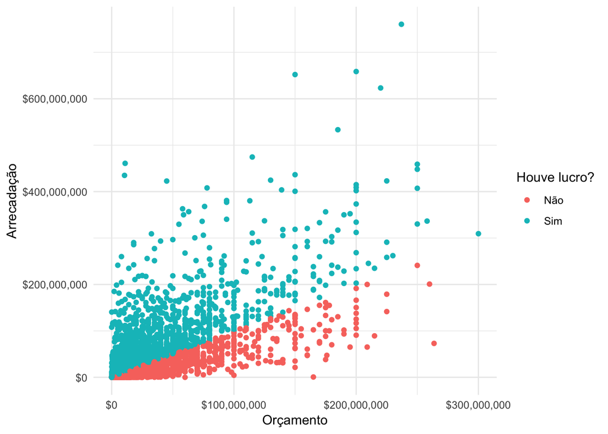

O gráfico abaixo nos permite visualizar conjuntamente as seguintes variáveis:

- Orçamento
- Nota IMDB
- Classificação etária (a partir de 13 anos ou livre)
- Data de lançamento (antigo ou recente)

[figure not shown]

A seguir, os diretores com mais filmes na base do IMDB.

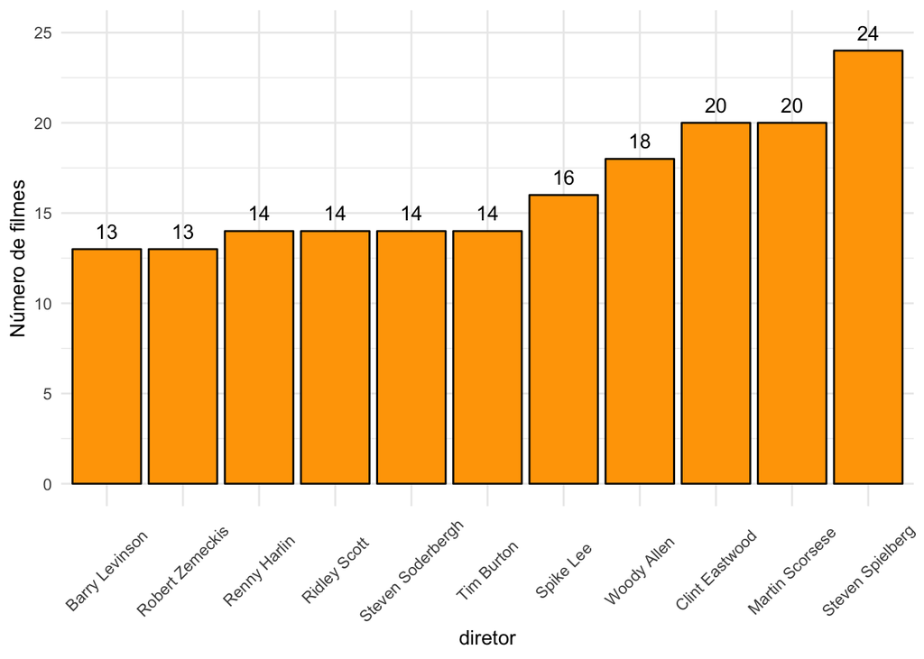

Os boxplots abaixo mostram a distribuição do balanço financeiro dos filmes dos 5 diretores com mais filmes na base do IMDB.

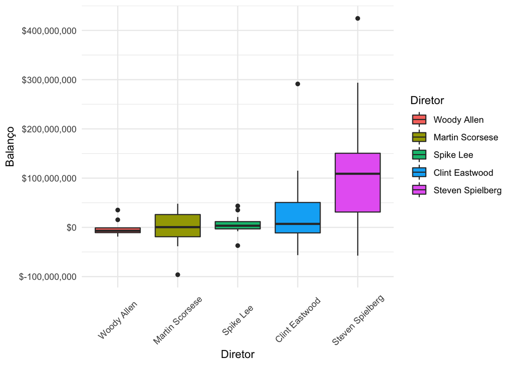

### Exercícios

1. Na função `knitr::opts_chunk$set`, o que acontece se você mudar o argumento `echo` para `TRUE`.
2. Na função `knitr::opts_chunk$set`, o que acontece se você mudar o argumento `warning` para `TRUE`.
3. Na função `knitr::opts_chunk$set`, o que acontece se você mudar o argumento `message` para `TRUE`.
4. Na função `knitr::opts_chunk$set`, o que acontece se você retirar o argumento `fig.align`?
5. Crie um novo arquivo R Markdown chamado `exercicios.Rmd`. O *output* desse arquivo deve ser **HTML**. Neste novo arquivo, copie os *chunks* da tabela e gráficos acima, fazendo as seguintes modificações.
1. Refaça a tabela pegando os filmes do Steven Spielberg e acrescentando as informações de orçamento, receita e balanço. Formate esses valores para ficar na unidade de medida *milhões de dólares*.
2. Transforme o gráfico da **Arrecadação vs Orçamento** por um gráfico do **Balanço vs nota IMDB**.
3. Transforme o gráfico do **Orçamento vs Nota IMDB** retirando o mapeamento da cor dos pontos.
4. No gráfico de barras, coloque o número de filmes no centro de cada barra.
5. Nos boxplots, deixe o preenchimento das caixinhas em branco e mapeie o contorno dela à variavel diretor.
6. Compile o relatório também para PDF.